# HLS Example (https)

The Harmonized Landsat Sentinel 2 dataset contains grid-aligned cloud-optimized geotiffs that are great for deep time series analysis because it contains the combined archives from Landsat 8/9 and Sentinel 2A/B/C. NASA MAAP maintains a [stac-geoparquet archive](https://maap-project.github.io/hls-stac-geoparquet-archive/) of all of the HLS STAC records. This archive solves a common bottleneck that users have encountered when trying to work with HLS STAC records at scale by eliminating the need to query the CMR STAC API!

This notebook demonstrates how to use lazycogs to interact with the HLS STAC Geoparquet Archive in the optimal way.

**Note:** This tutorial shows how to access the HLS granules using https links. If you are able to run your compute in the AWS us-west-2 region, try the method outlined in HLS Example (us-west-2 only).

```python
import asyncio
import os
from urllib.parse import urlparse

import requests
from async_geotiff import GeoTIFF
from obstore.exceptions import NotFoundError, PermissionDeniedError
from obstore.store import HTTPStore, LocalStore, from_url
from pyproj import Transformer
from rustac import DuckdbClient

import lazycogs

HLS_STAC_GEOPARQUET_PREFIX = "s3://nasa-maap-data-store/file-staging/nasa-map"
HLS_STAC_GEOPARQUET_PATH_FORMAT = (
    "hls-stac-geoparquet-archive/v2/{collection}"
    "/year={year}/month={month}/{collection}-{year}-{month}.parquet"
)
HLS_STAC_GEOPARQUET_HREF = (
    HLS_STAC_GEOPARQUET_PREFIX + "/" + HLS_STAC_GEOPARQUET_PATH_FORMAT
)

HLS_STAC_GEOPARQUET_HIVE_FORMAT = (
    "hls-stac-geoparquet-archive/v2/{collection}/**/*.parquet"
)
```

import asyncio import os from urllib.parse import urlparse import requests from async_geotiff import GeoTIFF from obstore.exceptions import NotFoundError, PermissionDeniedError from obstore.store import HTTPStore, LocalStore, from_url from pyproj import Transformer from rustac import DuckdbClient import lazycogs HLS_STAC_GEOPARQUET_PREFIX = "s3://nasa-maap-data-store/file-staging/nasa-map" HLS_STAC_GEOPARQUET_PATH_FORMAT = ( "hls-stac-geoparquet-archive/v2/{collection}" "/year={year}/month={month}/{collection}-{year}-{month}.parquet" ) HLS_STAC_GEOPARQUET_HREF = ( HLS_STAC_GEOPARQUET_PREFIX + "/" + HLS_STAC_GEOPARQUET_PATH_FORMAT ) HLS_STAC_GEOPARQUET_HIVE_FORMAT = ( "hls-stac-geoparquet-archive/v2/{collection}/**/*.parquet" )

### Download some of the HLS STAC Geoparquet Archive

The HLS STAC Geoparquet Archive is stored in a pair of hive-partitioned parquet dataset (one each for HLSS30 and HLSL30). The files are publicly accessible but duckdb requires `ListBucket` privileges in order to use the hive-partitioning structure. Since `ListBucket` privileges are not granted to the general public, an alternative is to copy the files you want to a store for which you have full privileges (e.g. your own bucket, local disk).

The following example will download all of the available files for the years 2025 and 2026 (as of May 13, 2026 this is ~1.4 GB).

```python
hls_s3_parquet_store = from_url(
    HLS_STAC_GEOPARQUET_PREFIX,
    region="us-west-2",
    skip_signature=True,
)
hls_local_parquet_store = LocalStore(prefix="data")

hls_stac_geoparquet_paths = [
    HLS_STAC_GEOPARQUET_PATH_FORMAT.format(
        collection=collection,
        year=year,
        month=month,
    )
    for collection in ["HLSS30_2.0", "HLSL30_2.0"]
    for year in [2025, 2026]
    for month in range(1, 13)
]


async def _check_exists(store, path) -> bool:
    try:
        _ = await store.head_async(path)
    except (FileNotFoundError, NotFoundError, PermissionDeniedError):
        return False
    else:
        return True


async def download_if_missing(path):
    exists_on_s3 = await _check_exists(hls_s3_parquet_store, path)
    exists_locally = await _check_exists(hls_local_parquet_store, path)

    if exists_on_s3 and not exists_locally:
        resp = await hls_s3_parquet_store.get_async(path)
        await hls_local_parquet_store.put_async(path, resp)


tasks = [download_if_missing(p) for p in hls_stac_geoparquet_paths]
_ = await asyncio.gather(*tasks)
```

hls_s3_parquet_store = from_url( HLS_STAC_GEOPARQUET_PREFIX, region="us-west-2", skip_signature=True, ) hls_local_parquet_store = LocalStore(prefix="data") hls_stac_geoparquet_paths = [ HLS_STAC_GEOPARQUET_PATH_FORMAT.format( collection=collection, year=year, month=month, ) for collection in ["HLSS30_2.0", "HLSL30_2.0"] for year in [2025, 2026] for month in range(1, 13) ] async def _check_exists(store, path) -> bool: try: _ = await store.head_async(path) except (FileNotFoundError, NotFoundError, PermissionDeniedError): return False else: return True async def download_if_missing(path): exists_on_s3 = await _check_exists(hls_s3_parquet_store, path) exists_locally = await _check_exists(hls_local_parquet_store, path) if exists_on_s3 and not exists_locally: resp = await hls_s3_parquet_store.get_async(path) await hls_local_parquet_store.put_async(path, resp) tasks = [download_if_missing(p) for p in hls_stac_geoparquet_paths] _ = await asyncio.gather(*tasks)

### Set up a duckdb client for rustac

rustac can be configured to search your local copy of the HLS STAC Geoparquet Archive, taking advantage of the hive-partitioned structure.

```python
duckdb_client = DuckdbClient(use_hive_partitioning=True)
```

duckdb_client = DuckdbClient(use_hive_partitioning=True)

### Define the array's spatial extent

The HLS granules are projected in UTM coordinate reference systems. To access the underlying data in an undistorted efficient manner the best way is to build an array for a single UTM coordinate system that is aligned with the grid of the COGs themselves.

We can define an AOI for an entire UTM zone like this:

```python
epsg_code = "32615"
utm_zone = 15
dst_crs = f"epsg:{epsg_code}"

east_edge = (utm_zone * 6) - 180
west_edge = east_edge - 6
bbox_4326 = (west_edge, 0, east_edge, 84)

# transform to epsg:4326 for STAC search
transformer = Transformer.from_crs("epsg:4326", dst_crs, always_xy=True)
dst_bbox = transformer.transform_bounds(*bbox_4326)

print(bbox_4326)
print(dst_bbox)
```

epsg_code = "32615" utm_zone = 15 dst_crs = f"epsg:{epsg_code}" east_edge = (utm_zone * 6) - 180 west_edge = east_edge - 6 bbox_4326 = (west_edge, 0, east_edge, 84) # transform to epsg:4326 for STAC search transformer = Transformer.from_crs("epsg:4326", dst_crs, always_xy=True) dst_bbox = transformer.transform_bounds(*bbox_4326) print(bbox_4326) print(dst_bbox)

```
(-96, 0, -90, 84)
(166021.44308053772, 0.0, 833978.5569194595, 9329005.182447437)
```

Retrieve a single STAC item so we can snap our approximate bounding box to the HLS granule grid.

```python
sample_item = duckdb_client.search(
    "data/" + HLS_STAC_GEOPARQUET_HIVE_FORMAT.format(collection="HLSS30_2.0"),
    bbox=bbox_4326,
    filter={"op": "=", "args": [{"property": "proj:epsg"}, epsg_code]},
    max_items=1,
)[0]
```

sample_item = duckdb_client.search( "data/" + HLS_STAC_GEOPARQUET_HIVE_FORMAT.format(collection="HLSS30_2.0"), bbox=bbox_4326, filter={"op": "=", "args": [{"property": "proj:epsg"}, epsg_code]}, max_items=1, )[0]

Use the `proj:transform` property to align our rough bounding box with the HLS grid

```python
dst_bbox_aligned = lazycogs.align_bbox(
    sample_item["properties"]["proj:transform"],
    dst_bbox,
)

print(f"aligned bbox: {dst_bbox_aligned}")
```

dst_bbox_aligned = lazycogs.align_bbox( sample_item["properties"]["proj:transform"], dst_bbox, ) print(f"aligned bbox: {dst_bbox_aligned}")

```
aligned bbox: (166020.0, 0.0, 834000.0, 9329010.0)
```

### Configure access to the HLS COGs over HTTP

The STAC assets in the stac-geoparquet file contain `https` hrefs but they require an EDL token to access. obstore's `HTTPStore` allows you to provide the `Authorization: Bearer <token>` header via `default_headers` in the `client_options` dict.

This will work for you if you have your NASA Earthdata credentials stored in the `EARTHDATA_USERNAME` and `EARTHDATA_PASSWORD` environment variables.

```python
def get_earthdata_token(username: str, password: str) -> str:
    r = requests.post(
        "https://urs.earthdata.nasa.gov/api/users/find_or_create_token",
        auth=(username, password),
        timeout=10,
    )
    r.raise_for_status()
    return r.json()["access_token"]


token = get_earthdata_token(
    os.getenv("EARTHDATA_USERNAME"),
    os.getenv("EARTHDATA_PASSWORD"),
)

store_prefix = "https://data.lpdaac.earthdatacloud.nasa.gov"

store = HTTPStore(
    store_prefix,
    client_options={
        "default_headers": {
            "Authorization": f"Bearer {token}",
        },
    },
)
```

def get_earthdata_token(username: str, password: str) -> str: r = requests.post( "https://urs.earthdata.nasa.gov/api/users/find_or_create_token", auth=(username, password), timeout=10, ) r.raise_for_status() return r.json()["access_token"] token = get_earthdata_token( os.getenv("EARTHDATA_USERNAME"), os.getenv("EARTHDATA_PASSWORD"), ) store_prefix = "https://data.lpdaac.earthdatacloud.nasa.gov" store = HTTPStore( store_prefix, client_options={ "default_headers": { "Authorization": f"Bearer {token}", }, }, )

### Inspect a sample COG

We can use async-geotiff to inspect a sample COG and its overviews:

```python
geotiff = await GeoTIFF.open(
    urlparse(sample_item["assets"]["B04"]["href"]).path,
    store=store,
)

resolutions = [geotiff.res[0]]
print("full resolution:", geotiff.res)

for i, overview in enumerate(geotiff.overviews, start=1):
    resolutions.append(overview.res[0])
    print("overview", i, overview.res)

print("nodata value:", geotiff.nodata)
print("data type:", geotiff.dtype)
```

geotiff = await GeoTIFF.open( urlparse(sample_item["assets"]["B04"]["href"]).path, store=store, ) resolutions = [geotiff.res[0]] print("full resolution:", geotiff.res) for i, overview in enumerate(geotiff.overviews, start=1): resolutions.append(overview.res[0]) print("overview", i, overview.res) print("nodata value:", geotiff.nodata) print("data type:", geotiff.dtype)

```
full resolution: (30.0, 30.0)
overview 1 (60.0, 60.0)
overview 2 (120.0, 120.0)
overview 3 (239.73799126637556, 239.73799126637556)
overview 4 (479.4759825327511, 479.4759825327511)
nodata value: -9999.0
data type: int16
```

### Open a massive array

```python
stac_search_args = {
    "href": "data/" + HLS_STAC_GEOPARQUET_HIVE_FORMAT.format(collection="HLSS30_2.0"),
    "filter": {"op": "=", "args": [{"property": "proj:epsg"}, epsg_code]},
}

da = lazycogs.open(
    crs=dst_crs,
    bbox=dst_bbox_aligned,
    resolution=30,
    time_period="P1D",  # one time coordinate per day
    bands=["B04", "B03", "B02"],
    dtype=geotiff.dtype,
    nodata=geotiff.nodata,
    store=store,
    **stac_search_args,
)

da
```

stac_search_args = { "href": "data/" + HLS_STAC_GEOPARQUET_HIVE_FORMAT.format(collection="HLSS30_2.0"), "filter": {"op": "=", "args": [{"property": "proj:epsg"}, epsg_code]}, } da = lazycogs.open( crs=dst_crs, bbox=dst_bbox_aligned, resolution=30, time_period="P1D", # one time coordinate per day bands=["B04", "B03", "B02"], dtype=geotiff.dtype, nodata=geotiff.nodata, store=store, **stac_search_args, ) da

```
<xarray.DataArray (band: 3, time: 494, y: 310967, x: 22266)> Size: 21TB
[10261354991004 values with dtype=int16]
Coordinates:
  * band         (band) <U3 36B 'B04' 'B03' 'B02'
  * time         (time) datetime64[s] 4kB 2025-01-01 2025-01-02 ... 2026-05-09
  * y            (y) float64 2MB 9.329e+06 9.329e+06 9.329e+06 ... 45.0 15.0
  * x            (x) float64 178kB 1.66e+05 1.661e+05 ... 8.34e+05 8.34e+05
    spatial_ref  int64 8B 0
Indexes:
  ┌ x        RasterIndex (crs=EPSG:32615)
  └ y
Attributes:
    grid_mapping:            spatial_ref
    zarr_conventions:        [{'schema_url': 'https://raw.githubusercontent.c...
    spatial:dimensions:      ['y', 'x']
    spatial:bbox:            (166020.0, 0.0, 834000.0, 9329010.0)
    spatial:transform_type:  affine
    spatial:transform:       [30.0, 0.0, 166020.0, 0.0, -30.0, 9329010.0]
    spatial:shape:           [310967, 22266]
    spatial:registration:    pixel
    _stac_backend:           MultiBandStacBackendArray(bands=['B04', 'B03', '...
    _stac_time_coords:       2025-01-01 … 2026-05-09 (n=494)
    proj:code:               EPSG:32615
```

Extract all values for a single point.

```python
%%time
pt = da.sel(
    x=576465,
    y=5196159,
    method="nearest",
).load()

pt
```

%%time pt = da.sel( x=576465, y=5196159, method="nearest", ).load() pt

```
CPU times: user 1min 53s, sys: 8.13 s, total: 2min 1s
Wall time: 36.4 s
```

```
<xarray.DataArray (band: 3, time: 494)> Size: 3kB
array([[-9999, -9999,  5404, ..., -9999,  1649, -9999],
       [-9999, -9999,  5062, ..., -9999,  1705, -9999],
       [-9999, -9999,  4619, ..., -9999,  1721, -9999]],
      shape=(3, 494), dtype=int16)
Coordinates:
  * band         (band) <U3 36B 'B04' 'B03' 'B02'
  * time         (time) datetime64[s] 4kB 2025-01-01 2025-01-02 ... 2026-05-09
    spatial_ref  int64 8B 0
    x            float64 8B 5.765e+05
    y            float64 8B 5.196e+06
Attributes:
    grid_mapping:            spatial_ref
    zarr_conventions:        [{'schema_url': 'https://raw.githubusercontent.c...
    spatial:dimensions:      ['y', 'x']
    spatial:bbox:            (166020.0, 0.0, 834000.0, 9329010.0)
    spatial:transform_type:  affine
    spatial:transform:       [30.0, 0.0, 166020.0, 0.0, -30.0, 9329010.0]
    spatial:shape:           [310967, 22266]
    spatial:registration:    pixel
    _stac_backend:           MultiBandStacBackendArray(bands=['B04', 'B03', '...
    _stac_time_coords:       2025-01-01 … 2026-05-09 (n=494)
    proj:code:               EPSG:32615
```

### Operate on a subset in space and time

Select a spatial subset for the days with non-nodata values in the point extraction.

```python
subset = da.sel(
    x=slice(550_000, 600_000),
    y=slice(5_200_000, 5_150_000),
    time=pt.time.values[pt.isel(band=0).values != geotiff.nodata],
).sel(time=slice("2026-03-01", "2026-03-11"))

subset
```

subset = da.sel( x=slice(550_000, 600_000), y=slice(5_200_000, 5_150_000), time=pt.time.values[pt.isel(band=0).values != geotiff.nodata], ).sel(time=slice("2026-03-01", "2026-03-11")) subset

```
<xarray.DataArray (band: 3, time: 4, y: 1668, x: 1668)> Size: 67MB
[33386688 values with dtype=int16]
Coordinates:
  * band         (band) <U3 36B 'B04' 'B03' 'B02'
  * time         (time) datetime64[s] 32B 2026-03-01 2026-03-04 ... 2026-03-11
  * y            (y) float64 13kB 5.2e+06 5.2e+06 5.2e+06 ... 5.15e+06 5.15e+06
  * x            (x) float64 13kB 5.5e+05 5.5e+05 5.501e+05 ... 6e+05 6e+05
    spatial_ref  int64 8B 0
Indexes:
  ┌ x        RasterIndex (crs=EPSG:32615)
  └ y
Attributes:
    grid_mapping:            spatial_ref
    zarr_conventions:        [{'schema_url': 'https://raw.githubusercontent.c...
    spatial:dimensions:      ['y', 'x']
    spatial:bbox:            (166020.0, 0.0, 834000.0, 9329010.0)
    spatial:transform_type:  affine
    spatial:transform:       [30.0, 0.0, 166020.0, 0.0, -30.0, 9329010.0]
    spatial:shape:           [310967, 22266]
    spatial:registration:    pixel
    _stac_backend:           MultiBandStacBackendArray(bands=['B04', 'B03', '...
    _stac_time_coords:       2025-01-01 … 2026-05-09 (n=494)
    proj:code:               EPSG:32615
```

```python
%%time
_ = subset.load()
```

%%time _ = subset.load()

```
CPU times: user 4.91 s, sys: 1.48 s, total: 6.39 s
Wall time: 7.78 s
```

```python
(
    subset.plot.imshow(
        rgb="band",
        col="time",
        col_wrap=2,
        vmin=0,
        vmax=2000,
        size=4,
        aspect=subset.shape[3] / subset.shape[2],
    )
)
```

( subset.plot.imshow( rgb="band", col="time", col_wrap=2, vmin=0, vmax=2000, size=4, aspect=subset.shape[3] / subset.shape[2], ) )

```
<xarray.plot.facetgrid.FacetGrid at 0x7f1e48e99a90>
```

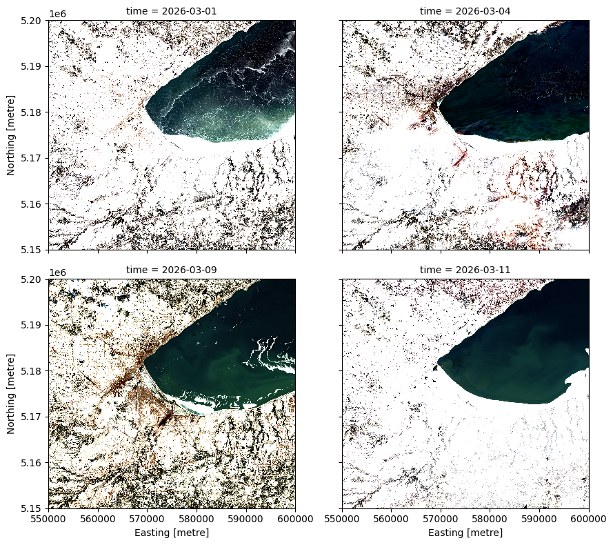